# Tugas Hands On 1

#### NAMA : MARSELLA YESI NATALIA SINAGA

#### NIM : 121140174

#### MATA KULIAH : SISTEM / TEKNOLOGI MULTIMEDIA

1. Buktikan bahwa terdapat perbedaan yang signifikan pada visualisasi audio menggunakan 5 buah sumber audio yang berbeda:\n
- Pertama, bersuara pelan. Kedua, relatif bersuara dengan volume sedang. Ketiga, relatif bersuara dengan volume tinggi. Keempat, bersuara volume sedang, namun mengucapkan kata-kata dengan huruf `s` yang panjang (`essssss`). Kelima, bersuara volume sedang, mengucapkan kata `brrbrbrbrb` / lip trill.
- Masing-masing silahkan membuat file wav/mp3/flac yang sesuai dengan ketentuan tersebut (5 file).
- Gunakan waveforms dan spectogram untuk memvisualisasikan ketiga sumber audio tersebut.
- Berikan analisa anda terhadap perbedaan visualisasi audio tersebut.

```python
import matplotlib.pyplot as plt
import numpy as np
import os
import wave
import librosa
import librosa.display
```

```python
volumerendah = os.path.join(os.getcwd(), 'data', 'spoken.wav')
```

```python
# Periksa jika file tidak ditemukan
if not os.path.exists(volumerendah):
    print(f"File {volumerendah} not found.")
    exit()
```

```python
# Membaca file WAV
with wave.open(volumerendah, 'r') as wav_file:
    frames = wav_file.readframes(-1)
    panjangisisample = np.frombuffer(frames, dtype='int16')
    frsample = wav_file.getframerate()

    # Mendapatkan informasi channel
    volumerendahchannel = wav_file.getnchannels()
```

```python
# Tampilkan informasi file WAV
print(f"Isi dari sound_data: {panjangisisample}")
print(f"Panjang dari sound_data: {len(panjangisisample)}")
print(f"Sampling rate: {frsample}")
print(f"Jumlah channel: {volumerendahchannel}")
```

```
Isi dari sound_data: [0 0 0 ... 0 0 0]
Panjang dari sound_data: 347904
Sampling rate: 44100
Jumlah channel: 2
```

```python
# Membagi channel menjadi dua bagian (kiri dan kanan)
panjangisisample = panjangisisample.reshape(-1, volumerendahchannel)
print(f"Panjang isi sample setelah direshape: {len(panjangisisample)}")

audiokiri_volrendah = panjangisisample[:, 0]
audiokanan_volrendah = panjangisisample[:, 1]

print(f"Panjang audio kiri: {len(audiokiri_volrendah)}")
print(f"Panjang audio kanan: {len(audiokanan_volrendah)}")
```

```
Panjang isi sample setelah direshape: 173952
Panjang audio kiri: 173952
Panjang audio kanan: 173952
```

```python
# Melakukan plotting audio kiri
panjangsampelkiri = len(audiokiri_volrendah)
print(f"Panjang sampel per sisi: {panjangsampelkiri}")

durasi_spoken = panjangsampelkiri / frsample
print(f"Panjang spoken.wav: {durasi_spoken}")

# Membuat sumbu waktu
time_axis = np.linspace(0, durasi_spoken, panjangsampelkiri)
```

```
Panjang sampel per sisi: 173952
Panjang spoken.wav: 3.944489795918367
```

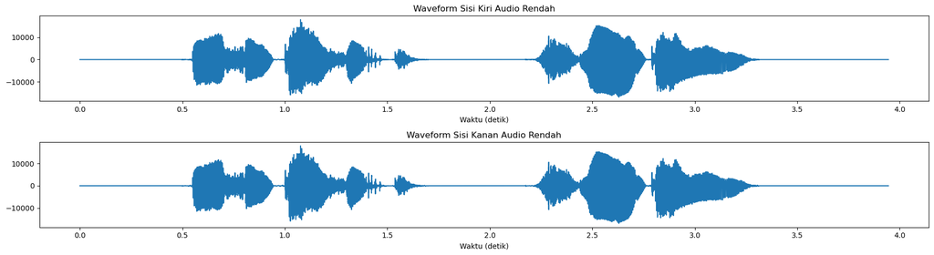

```python
# Plotting audio kiri dan kanan
ax, fig = plt.subplots(2, 1, figsize=(18, 5))
fig[0].plot(time_axis, audiokiri_volrendah, label='Kiri')
fig[0].set_title('Waveform Sisi Kiri Audio Rendah')
fig[0].set_xlabel('Waktu (detik)')
fig[1].plot(time_axis, audiokanan_volrendah, label='Kanan')
fig[1].set_title('Waveform Sisi Kanan Audio Rendah')
fig[1].set_xlabel('Waktu (detik)')
plt.tight_layout()
plt.show()
```

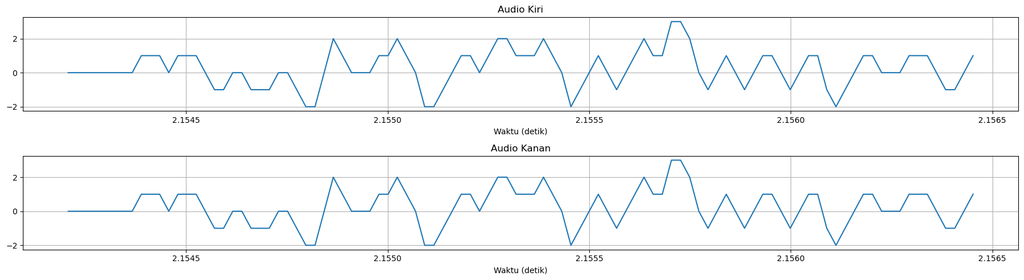

```python
# Plotting audio kiri dan kanan dengan zoom di rentang durasi 2 detik
ax, fig = plt.subplots(2, 1, figsize=(18, 5))
fig[0].plot(time_axis[95000:95100], audiokiri_volrendah[95000:95100], label='Kiri')
fig[0].set_title('Audio Kiri')
fig[0].set_xlabel('Waktu (detik)')
fig[0].grid()
fig[1].plot(time_axis[95000:95100], audiokanan_volrendah[95000:95100], label='Kanan')
fig[1].set_title('Audio Kanan')
fig[1].set_xlabel('Waktu (detik)')
fig[1].grid()
plt.tight_layout()
plt.show()
```

```python
print(f"Isi audio kiri: {audiokiri_volrendah[95000:95100]}")
print(f"Isi audio kanan: {audiokanan_volrendah[95000:95100]}")
```

```
Isi audio kiri: [ 0  0  0  0  0  0  0  0  1  1  1  0  1  1  1  0 -1 -1  0  0 -1 -1 -1  0
  0 -1 -2 -2  0  2  1  0  0  0  1  1  2  1  0 -2 -2 -1  0  1  1  0  1  2
  2  1  1  1  2  1  0 -2 -1  0  1  0 -1  0  1  2  1  1  3  3  2  0 -1  0
  1  0 -1  0  1  1  0 -1  0  1  1 -1 -2 -1  0  1  1  0  0  0  1  1  1  0
 -1 -1  0  1]
Isi audio kanan: [ 0  0  0  0  0  0  0  0  1  1  1  0  1  1  1  0 -1 -1  0  0 -1 -1 -1  0
  0 -1 -2 -2  0  2  1  0  0  0  1  1  2  1  0 -2 -2 -1  0  1  1  0  1  2
  2  1  1  1  2  1  0 -2 -1  0  1  0 -1  0  1  2  1  1  3  3  2  0 -1  0
  1  0 -1  0  1  1  0 -1  0  1  1 -1 -2 -1  0  1  1  0  0  0  1  1  1  0
 -1 -1  0  1]
```

```python
# Memuat audio menggunakan Librosa
data_audio, sr = librosa.load(volumerendah)
S = librosa.stft(data_audio)
S_db = librosa.amplitude_to_db(np.abs(S))

print(f"Sampling Rate: {sr}")
```

```
Sampling Rate: 22050
```

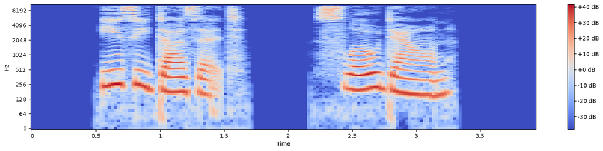

```python
# Plotting spektrogram
plt.figure(figsize=(20, 4))
librosa.display.specshow(S_db, sr=sr, x_axis='time', y_axis='log', cmap='coolwarm')
plt.colorbar(format='%+2.0f dB')
plt.show()
```

audio tersebut memiliki dominasi frekuensi rendah, terutama pada rentang frekuensi 100-200 Hz, yang menandakan adanya bass yang kuat. Terlihat juga adanya puncak frekuensi pada rentang 500-600 Hz, yang menunjukkan suara vokal atau instrumental yang kuat pada frekuensi tersebut. Namun, spektrogram ini juga menunjukkan bahwa audio tersebut memiliki kurangnya frekuensi tinggi, terutama pada rentang 8000-10000 Hz, yang menandakan bahwa treble dalam audio ini kurang kuat. Selain itu, terdapat pola berulang pada spektrogram, terutama di rentang frekuensi 100-200 Hz dan 500-600 Hz, yang mengindikasikan adanya ritme atau pola suara yang konsisten dalam audio. Berdasarkan karakteristik visual tersebut, dapat disimpulkan bahwa audio ini memiliki bass yang kuat, vokal atau instrumen yang jelas, tetapi dengan treble yang kurang kuat, serta menunjukkan pola suara yang konsisten.

```python
volumesedang = os.path.join(os.getcwd(), 'data', 'wind.wav')
```

```python
# Periksa jika file tidak ditemukan
if not os.path.exists(volumesedang):
    print(f"File {volumesedang} not found.")
    exit()
```

```python
# Membaca file WAV
with wave.open(volumesedang, 'r') as wav_file:
    framessedang = wav_file.readframes(-1)
    panjangsamplesedang = np.frombuffer(framessedang, dtype='int16')
    frsamplesedang = wav_file.getframerate()

    # Mendapatkan informasi channel
    volumesedangchannel = wav_file.getnchannels()
```

```python
# Tampilkan informasi file WAV
print(f"Isi dari sound_data: {panjangsamplesedang}")
print(f"Panjang dari sound_data: {len(panjangsamplesedang)}")
print(f"Sampling rate: {frsamplesedang}")
print(f"Jumlah channel: {volumesedangchannel}")
```

```
Isi dari sound_data: [0 0 0 ... 0 0 0]
Panjang dari sound_data: 965376
Sampling rate: 44100
Jumlah channel: 2
```

```python
# Membagi channel menjadi dua bagian (kiri dan kanan)
panjangsamplesedang = panjangsamplesedang.reshape(-1, volumesedangchannel)
print(f"Panjang isi sample setelah direshape: {len(panjangsamplesedang)}")

audiokiri_volsedang = panjangsamplesedang[:, 0]
audiokanan_volsedang = panjangsamplesedang[:, 1]
print(f"Panjang audio kiri: {len(audiokiri_volsedang)}")
print(f"Panjang audio kanan: {len(audiokanan_volsedang)}")
```

```
Panjang isi sample setelah direshape: 482688
Panjang audio kiri: 482688
Panjang audio kanan: 482688
```

```python
# Melakukan plotting audio kiri
panjangsampelsedang = len(audiokiri_volsedang)
print(f"Panjang sampel per sisi: {panjangsampelsedang}")

durasi_wind = panjangsampelsedang / frsamplesedang
print(f"Panjang wind.wav: {durasi_wind}")

# Membuat sumbu waktu
time_axis = np.linspace(0, durasi_wind, panjangsampelsedang)
```

```
Panjang sampel per sisi: 482688
Panjang wind.wav: 10.94530612244898
```

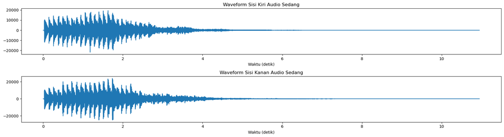

```python
# Plotting audio kiri dan kanan
ax, fig = plt.subplots(2, 1, figsize=(18, 5))
fig[0].plot(time_axis, audiokiri_volsedang, label='Kiri')
fig[0].set_title('Waveform Sisi Kiri Audio Sedang')
fig[0].set_xlabel('Waktu (detik)')
fig[1].plot(time_axis, audiokanan_volsedang, label='Kanan')
fig[1].set_title('Waveform Sisi Kanan Audio Sedang')
fig[1].set_xlabel('Waktu (detik)')
plt.tight_layout()
plt.show()
```

Dalam waveform audio menampilkan dua kanal stereo, yaitu sisi kiri dan kanan, dengan durasi keseluruhan sekitar 10 detik. Suara utama terdengar dari detik 0 hingga sekitar detik 4,5, sedangkan setelah detik 4,5 hingga akhir grafik terlihat garis lurus yang menunjukkan tidak adanya suara (silence). Pada fase awal, antara detik 0 hingga 1,5, amplitudo gelombang memperlihatkan puncak-puncak tajam dan fluktuasi yang konstan, menandakan adanya suara dengan volume tinggi atau intensitas kuat. Secara bertahap, amplitudo suara menurun hingga mendekati nol pada sekitar detik 4,5, yang menandakan bahwa energi suara perlahan memudar dan akhirnya menghilang.

Kedua kanal, baik kiri maupun kanan, memiliki pola gelombang yang hampir serupa, menunjukkan bahwa rekaman audio memiliki keseimbangan yang baik di kedua sisi. Tidak ada perbedaan signifikan antara kanal kiri dan kanan, yang mengindikasikan perekaman stereo yang seimbang atau audio mono yang dipancarkan ke kedua kanal. dan terlihat bahwa suara dimulai dengan intensitas yang tinggi dan secara bertahap berkurang sampai akhirnya berhenti. Bagian akhir dari audio yang tenang, mulai dari detik 4,5 hingga 10, menunjukkan kemungkinan jeda atau berakhirnya rekaman.

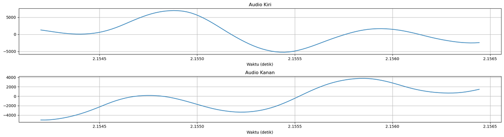

```python
# Plotting audio kiri dan kanan dengan zoom di rentang durasi 2 detik
ax, fig = plt.subplots(2, 1, figsize=(18, 5))
fig[0].plot(time_axis[95000:95100], audiokiri_volsedang[95000:95100], label='Kiri')
fig[0].set_title('Audio Kiri')
fig[0].set_xlabel('Waktu (detik)')
fig[0].grid()
fig[1].plot(time_axis[95000:95100], audiokanan_volsedang[95000:95100], label='Kanan')
fig[1].set_title('Audio Kanan')
fig[1].set_xlabel('Waktu (detik)')
fig[1].grid()
plt.tight_layout()
plt.show()
```

```python
print(f"Isi audio kiri: {audiokiri_volsedang[95000:95100]}")
print(f"Isi audio kanan: {audiokanan_volsedang[95000:95100]}")
```

```
Isi audio kiri: [ 1276  1093   902   708   524   359   225   131    78    67    99   182
   323   525   794  1130  1528  1982  2489  3034  3595  4147  4678  5176
  5629  6025  6357  6618  6806  6924  6970  6936  6810  6583  6244  5793
  5242  4609  3911  3158  2369  1564   763   -19  -772 -1488 -2162 -2789
 -3360 -3861 -4286 -4638 -4918 -5119 -5233 -5251 -5171 -4994 -4730 -4396
 -4009 -3580 -3116 -2631 -2142 -1659 -1192  -746  -324    74   443   775
  1063  1296  1473  1592  1655  1663  1617  1523  1383  1201   978   720
   433   124  -198  -525  -844 -1142 -1415 -1663 -1888 -2087 -2258 -2391
 -2479 -2517 -2503 -2438]
Isi audio kanan: [-5050 -5053 -5008 -4918 -4793 -4637 -4453 -4240 -3998 -3725 -3422 -3093
 -2742 -2373 -1994 -1620 -1265  -944  -660  -416  -215   -61    49   117
   147   144   110    40   -70  -221  -406  -621  -857 -1108 -1372 -1642
 -1913 -2178 -2431 -2660 -2860 -3027 -3165 -3274 -3349 -3384 -3374 -3321
 -3229 -3098 -2926 -2712 -2455 -2154 -1811 -1434 -1031  -607  -168   282
   727  1158  1567  1950  2303  2620  2896  3134  3333  3497  3625  3718
  3773  3784  3745  3655  3521  3349  3145  2912  2655  2382  2105  1840
  1599  1386  1200  1041   911   811   736   688   666   676   721   803
   923  1080  1264  1468]
```

```python
# Memuat audio menggunakan Librosa
data_audio, sr = librosa.load(volumesedang)
S = librosa.stft(data_audio)
S_db = librosa.amplitude_to_db(np.abs(S))

print(f"Sampling Rate: {sr}")
```

```
Sampling Rate: 22050
```

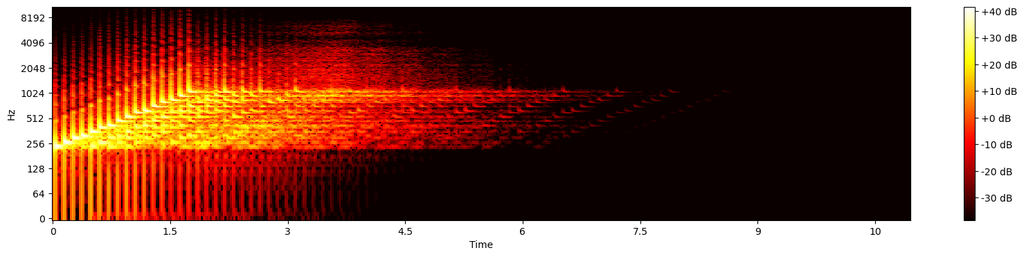

```python
# Plotting spektrogram
plt.figure(figsize=(20, 4))
librosa.display.specshow(S_db, sr=sr, x_axis='time', y_axis='log', cmap='hot')
plt.colorbar(format='%+2.0f dB')
plt.show()
```

```python
volumetinggi = os.path.join(os.getcwd(), 'data', 'highnote.wav')
```

```python
# Periksa jika file tidak ditemukan
if not os.path.exists(volumetinggi):
    print(f"File {volumetinggi} not found.")
    exit()
```

```python
# Membaca file WAV
with wave.open(volumetinggi, 'r') as wav_file:
    frames = wav_file.readframes(-1)
    panjangsamples = np.frombuffer(frames, dtype='int16')
    frsample = wav_file.getframerate()

    # Mendapatkan informasi channel
    volumetinggichannel = wav_file.getnchannels()
```

```python
# Tampilkan informasi file WAV
print(f"Isi dari sound_data: {panjangsamples}")
print(f"Panjang dari sound_data: {len(panjangsamples)}")
print(f"Sampling rate: {frsample}")
print(f"Jumlah channel: {volumetinggichannel}")
```

```
Isi dari sound_data: [0 0 0 ... 0 0 0]
Panjang dari sound_data: 1131264
Sampling rate: 48000
Jumlah channel: 2
```

```python
# Membagi channel menjadi dua bagian (kiri dan kanan)
panjangsamples = panjangsamples.reshape(-1, volumetinggichannel)
print(f"Panjang isi sample setelah direshape: {len(panjangsamples)}")

audiokiri_voltinggi = panjangsamples[:, 0]
audiokanan_voltinggi = panjangsamples[:, 1]
print(f"Panjang audio kiri: {len(audiokiri_voltinggi)}")
```

```
Panjang isi sample setelah direshape: 565632
Panjang audio kiri: 565632
```

```python
# Melakukan plotting audio kiri
panjangsampel = len(audiokiri_voltinggi)
print(f"Panjang sampel per sisi: {panjangsampel}")

durasi_highnote = panjangsampel / frsample
print(f"Panjang highnote.wav: {durasi_highnote}")

# Membuat sumbu waktu
time_axis = np.linspace(0, durasi_highnote, panjangsampel)
```

```
Panjang sampel per sisi: 565632
Panjang highnote.wav: 11.784
```

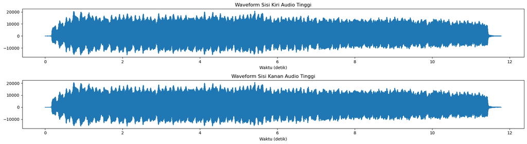

```python
# Plotting audio kiri dan kanan
ax, fig = plt.subplots(2, 1, figsize=(18, 5))
fig[0].plot(time_axis, audiokiri_voltinggi, label='Kiri')
fig[0].set_title('Waveform Sisi Kiri Audio Tinggi')
fig[0].set_xlabel('Waktu (detik)')
fig[1].plot(time_axis, audiokanan_voltinggi, label='Kanan')
fig[1].set_title('Waveform Sisi Kanan Audio Tinggi')
fig[1].set_xlabel('Waktu (detik)')
plt.tight_layout()
plt.show()
```

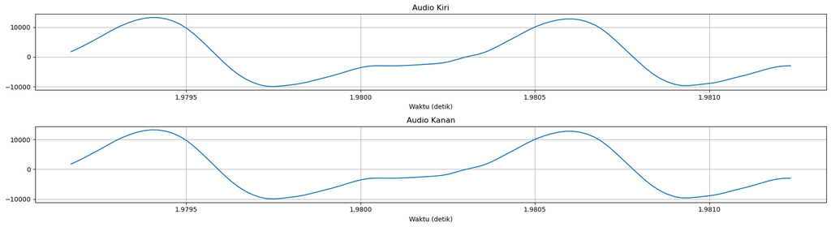

```python
# Plotting audio kiri dan kanan dengan zoom di rentang durasi 2 detik
ax, fig = plt.subplots(2, 1, figsize=(18, 5))
fig[0].plot(time_axis[95000:95100], audiokiri_voltinggi[95000:95100], label='Kiri')
fig[0].set_title('Audio Kiri')
fig[0].set_xlabel('Waktu (detik)')
fig[0].grid()
fig[1].plot(time_axis[95000:95100], audiokanan_voltinggi[95000:95100], label='Kanan')
fig[1].set_title('Audio Kanan')
fig[1].set_xlabel('Waktu (detik)')
fig[1].grid()
plt.tight_layout()
plt.show()
```

```python
print(f"Isi audio kiri: {audiokiri_voltinggi[95000:95100]}")
print(f"Isi audio kanan: {audiokanan_voltinggi[95000:95100]}")
```

```
Isi audio kiri: [ 1770  2875  4121  5404  6731  8105  9432 10602 11584 12383 12962 13247
 13198 12818 12099 10992  9453  7517  5304  2952   556 -1800 -3991 -5875
 -7389 -8565 -9413 -9878 -9949 -9759 -9482 -9162 -8732 -8167 -7544 -6927
 -6289 -5584 -4828 -4099 -3494 -3104 -2961 -2978 -3009 -2970 -2875 -2756
 -2614 -2463 -2309 -2068 -1611  -937  -236   333   869  1614  2668  3911
  5194  6487  7807  9092 10224 11143 11869 12420 12751 12782 12475 11836
 10843  9423  7559  5382  3095   811 -1457 -3642 -5573 -7126 -8313 -9164
 -9618 -9646 -9412 -9137 -8863 -8460 -7874 -7221 -6614 -6018 -5347 -4613
 -3920 -3380 -3063 -2973]
Isi audio kanan: [ 1770  2875  4121  5404  6731  8105  9432 10602 11584 12383 12962 13247
 13198 12818 12099 10992  9453  7517  5304  2952   556 -1800 -3991 -5875
 -7389 -8565 -9413 -9878 -9949 -9759 -9482 -9162 -8732 -8167 -7544 -6927
 -6289 -5584 -4828 -4099 -3494 -3104 -2961 -2978 -3009 -2970 -2875 -2756
 -2614 -2463 -2309 -2068 -1611  -937  -236   333   869  1614  2668  3911
  5194  6487  7807  9092 10224 11143 11869 12420 12751 12782 12475 11836
 10843  9423  7559  5382  3095   811 -1457 -3642 -5573 -7126 -8313 -9164
 -9618 -9646 -9412 -9137 -8863 -8460 -7874 -7221 -6614 -6018 -5347 -4613
 -3920 -3380 -3063 -2973]
```

```python
# Memuat audio menggunakan Librosa
data_audio, sr = librosa.load(volumetinggi)
S = librosa.stft(data_audio)
S_db = librosa.amplitude_to_db(np.abs(S))

print(f"Sampling Rate: {sr}")
```

```
Sampling Rate: 22050
```

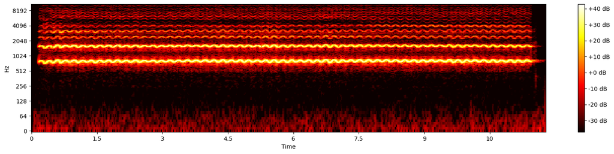

```python
# Plotting spektrogram
plt.figure(figsize=(20, 4))
librosa.display.specshow(S_db, sr=sr, x_axis='time', y_axis='log', cmap='hot')
plt.colorbar(format='%+2.0f dB')
plt.show()
```

Sumbu x (waktu) menunjukkan bahwa audio ini memiliki durasi lebih dari 10 detik. Sumbu y menunjukkan frekuensi dalam Hz, dengan rentang dari 0 Hz hingga 8192 Hz. Pada frekuensi yang lebih rendah, sekitar 500 Hz hingga 2000 Hz, terlihat garis-garis horizontal yang kuat. Garis-garis ini mengindikasikan komponen sinyal yang dominan pada frekuensi tersebut. Beberapa frekuensi mendominasi sinyal, terlihat jelas di sekitar 1000 Hz, 2000 Hz, dan 3000 Hz.Amplitudo tertinggi berada pada +40 dB, yang diwakili oleh warna kuning terang, sedangkan bagian-bagian dengan amplitudo rendah mendekati -30 dB diwakili oleh warna hitam.

```python
sss_sample = os.path.join(os.getcwd(), 'data', 'ssss.wav')
```

```python
# Periksa jika file tidak ditemukan
if not os.path.exists(sss_sample):
    print(f"File {sss_sample} not found.")
    exit()
```

```python
# Membaca file WAV
with wave.open(sss_sample, 'r') as wav_file:
    frames_sss = wav_file.readframes(-1)
    sample_sss = np.frombuffer(frames_sss, dtype='int16')
    fr_sss = wav_file.getframerate()

    # Mendapatkan informasi channel
    channel_sss = wav_file.getnchannels()
```

```python
# Tampilkan informasi file WAV
print(f"Isi dari sound_data: {sample_sss}")
print(f"Panjang dari sound_data: {len(sample_sss)}")
print(f"Sampling rate: {fr_sss}")
print(f"Jumlah channel: {channel_sss}")
```

```
Isi dari sound_data: [    0     0     0 ...   662 -2968 -2968]
Panjang dari sound_data: 491520
Sampling rate: 48000
Jumlah channel: 2
```

```python
# Membagi channel menjadi dua bagian (kiri dan kanan)
sample_sss = sample_sss.reshape(-1, channel_sss)
print(f"Panjang isi sample setelah direshape: {len(sample_sss)}")

audio_kiri_sss = sample_sss[:, 0]
audio_kanan_sss = sample_sss[:, 1]
print(f"Panjang audio kiri: {len(audio_kiri_sss)}")
print(f"Panjang audio kanan: {len(audio_kanan_sss)}")
```

```
Panjang isi sample setelah direshape: 245760
Panjang audio kiri: 245760
Panjang audio kanan: 245760
```

```python
# Melakukan plotting audio kiri
panjang_sampel_sss = len(audio_kiri_sss)
print(f"Panjang sampel per sisi: {panjang_sampel_sss}")

durasi_sss = panjang_sampel_sss / fr_sss
print(f"Panjang sss.wav: {durasi_sss}")

# Membuat sumbu waktu
time_axis = np.linspace(0, durasi_sss, panjang_sampel_sss)
```

```
Panjang sampel per sisi: 245760
Panjang sss.wav: 5.12
```

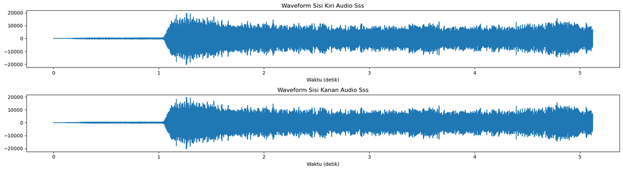

```python
# Plotting audio kiri dan kanan
ax, fig = plt.subplots(2, 1, figsize=(18, 5))
fig[0].plot(time_axis, audio_kiri_sss, label='Kiri')
fig[0].set_title('Waveform Sisi Kiri Audio Sss')
fig[0].set_xlabel('Waktu (detik)')
fig[1].plot(time_axis, audio_kanan_sss, label='Kanan')
fig[1].set_title('Waveform Sisi Kanan Audio Sss')
fig[1].set_xlabel('Waktu (detik)')
plt.tight_layout()
plt.show()
```

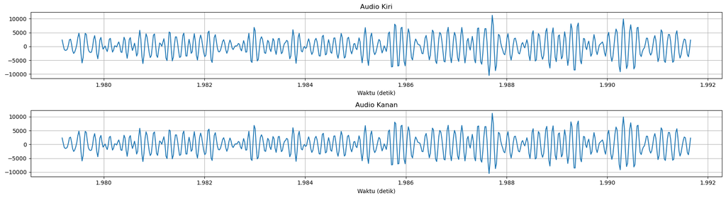

```python
# Plotting audio kiri dan kanan dengan zoom di rentang durasi 1 detik
ax, fig = plt.subplots(2, 1, figsize=(18, 5))
fig[0].plot(time_axis[95000:95600], audio_kiri_sss[95000:95600], label='Kiri')
fig[0].set_title('Audio Kiri')
fig[0].set_xlabel('Waktu (detik)')
fig[0].grid()
fig[1].plot(time_axis[95000:95600], audio_kanan_sss[95000:95600], label='Kanan')
fig[1].set_title('Audio Kanan')
fig[1].set_xlabel('Waktu (detik)')
fig[1].grid()
plt.tight_layout()
plt.show()
```

```python
# Memuat audio menggunakan Librosa
data_audio, sr = librosa.load(sss_sample)
S = librosa.stft(data_audio)
S_db = librosa.amplitude_to_db(np.abs(S))

print(f"Sampling Rate: {sr}")
```

```
Sampling Rate: 22050
```

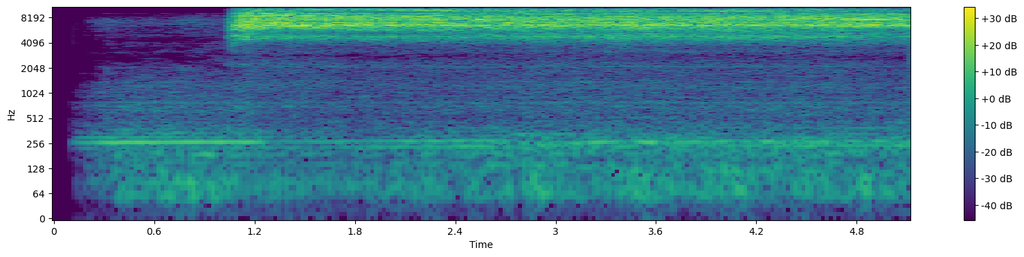

```python
# Plotting spektrogram
plt.figure(figsize=(20, 4))
librosa.display.specshow(S_db, sr=sr, x_axis='time', y_axis='log', cmap='viridis')
plt.colorbar(format='%+2.0f dB')
plt.show()
```

```python
brrb_sample = os.path.join(os.getcwd(), 'data', 'brbrr.wav')
```

```python
# Periksa jika file tidak ditemukan
if not os.path.exists(brrb_sample):
    print(f"File {brrb_sample} not found.")
    exit()
```

```python
# Membaca file WAV
with wave.open(brrb_sample, 'r') as wav_file:
    frames_brrb = wav_file.readframes(-1)
    sample_brrb = np.frombuffer(frames_brrb, dtype='int16')
    fr_brrb = wav_file.getframerate()

    # Mendapatkan informasi channel
    channel_brrb = wav_file.getnchannels()
```

```python
# Tampilkan informasi file WAV
print(f"Isi dari sound_data: {sample_brrb}")
print(f"Panjang dari sound_data: {len(sample_brrb)}")
print(f"Sampling rate: {fr_brrb}")
print(f"Jumlah channel: {channel_brrb}")
```

```
Isi dari sound_data: [   0    0    0 ... -246 -233 -233]
Panjang dari sound_data: 538624
Sampling rate: 48000
Jumlah channel: 2
```

```python
# Membagi channel menjadi dua bagian (kiri dan kanan)
sample_brrb = sample_brrb.reshape(-1, channel_brrb)
print(f"Panjang isi sample setelah direshape: {len(sample_brrb)}")

audio_kiri_brrb = sample_brrb[:, 0]
audio_kanan_brrb = sample_brrb[:, 1]
print(f"Panjang audio kiri: {len(audio_kiri_brrb)}")
print(f"Panjang audio kanan: {len(audio_kanan_brrb)}")
```

```
Panjang isi sample setelah direshape: 269312
Panjang audio kiri: 269312
Panjang audio kanan: 269312
```

```python
# Melakukan plotting audio kiri
panjang_sampel_brrb = len(audio_kiri_brrb)
print(f"Panjang sampel per sisi: {panjang_sampel_brrb}")

durasi_brrb = panjang_sampel_brrb / fr_brrb
print(f"Durasi brbrr.wav: {durasi_brrb}")

# Membuat sumbu waktu
time_axis = np.linspace(0, durasi_brrb, panjang_sampel_brrb)
```

```
Panjang sampel per sisi: 269312
Durasi brbrr.wav: 5.610666666666667
```

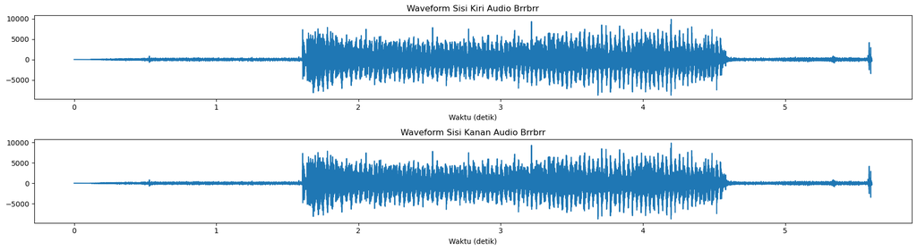

```python
# Plotting audio kiri dan kanan
ax, fig = plt.subplots(2, 1, figsize=(18, 5))
fig[0].plot(time_axis, audio_kiri_brrb, label='Kiri')
fig[0].set_title('Waveform Sisi Kiri Audio Brrbrr')
fig[0].set_xlabel('Waktu (detik)')
fig[1].plot(time_axis, audio_kanan_brrb, label='Kanan')
fig[1].set_title('Waveform Sisi Kanan Audio Brrbrr')
fig[1].set_xlabel('Waktu (detik)')
plt.tight_layout()
plt.show()
```

Dalam waveform audio ini menunjukkan dua kanal yaitu dengan kanal kiri dan kanal kanan. Pada bagian awal waveform, sekitar 0 hingga 1,5 detik, amplitudo sangat rendah mendekati nol, yang menunjukkan bahwa bagian awal audio relatif tenang atau hampir tidak ada suara yang terdengar. Namun, setelah titik ini, amplitudo mengalami peningkatan yang tajam, menandakan masuknya suara yang lebih keras dan lebih intens. Fase ini dimulai sekitar 1,5 detik dan berlangsung hingga sekitar 4,5 detik, di mana amplitudo tetap tinggi, mengindikasikan adanya aktivitas suara yang kuat dan berkelanjutan selama periode tersebut.